# DIVINE: Curated Datasets and Tools for Medical Data

Natàlia Pallarès Fontanet

Institut d’Investigacions Biomèdiques August Pi i Sunyer (IDIBAPS)  
Germans Trias i Pujol Research Institute and Hospital (IGTP)  
Barcelona, Spain

May 8, 2026

# Motivation

## DIVINE cohort

- Adult patients hospitalized
- SARS-CoV-2 infection
- 5 centers and 4 waves
- South metropolitan area of Barcelona
- Data stored in REDCap

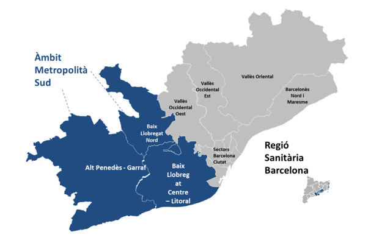

## DIVINE cohort

- Adult patients hospitalized
- SARS-CoV-2 infection
- 5 centers and 4 waves
- South metropolitan area of Barcelona
- Data stored in REDCap

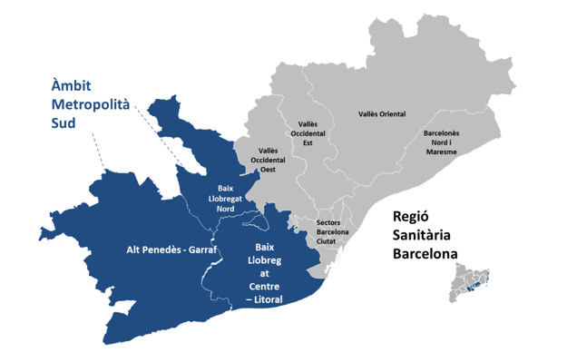

$\longrightarrow$ Make data available to support reproducible research and to enable its reuse

## Purposes

- Support education
- Validate existing predictive models
- Analyze the data
  - Clinical characteristics
  - Outcomes incidence
  - Prognostic factors

# DIVINE package

## DIVINE package

The DIVINE package contains:

- 14 datasets for 5813 patients
- 6 data management functions: inspect, clean, merge, summarize, visualize, and export data efficiently

## DIVINE Datasets

- Baseline datasets: `demographic`, `comorbidities`, `symptoms`, `vital_signs`, `analytics`, `concomitant_medication`, `scores`, and `vaccine`.
- Follow-up datasets: `icu`, `complications`, `inhosp_antivirals`, `inhosp_other_treatments`, `inhosp_antibiotics`, and `end_followup`.

**Note**

Common variables: ID, wave, and center of admission

## Demographic

Patient baseline demographics and lifestyle factors

| Record ID | COVID wave | Medical Center | Sex | Age | Smoker | Alcohol consumption (>3 UBE/day) | Long-term facilty |
| --- | --- | --- | --- | --- | --- | --- | --- |
| 1 | Wave 2 | Hospital C | Female | 84 | No | No | No |
| 2 | Wave 2 | Hospital A | Female | 33 | No | No | No |
| 3 | Wave 3 | Hospital A | Male | 64 | Ex-smoker | Yes | No |
| 4 | Wave 3 | Hospital A | Female | 65 | Ex-smoker | No | No |
| 5 | Wave 2 | Hospital C | Male | 49 | No | No | No |
| 6 | Wave 1 | Hospital C | Female | 40 | No | No | No |

## End-of-follow-up

Outcomes and end-of-follow-up variables

| Record ID | COVID wave | Medical Center | Days from hospital admission to clinical stability | Exitus | Days from hospital admission to exitus | Discharge | Days from hospital admission to discharge |
| --- | --- | --- | --- | --- | --- | --- | --- |
| 1 | Wave 2 | Hospital C | 0 | Yes | 13 | No | NA |
| 2 | Wave 2 | Hospital A | 3 | No | NA | Yes | 4 |
| 3 | Wave 3 | Hospital A | 13 | No | NA | Yes | 13 |
| 4 | Wave 3 | Hospital A | 12 | No | NA | Yes | 12 |
| 5 | Wave 2 | Hospital C | 0 | No | NA | Yes | 3 |
| 6 | Wave 1 | Hospital C | 43 | No | NA | Yes | 45 |

## DIVINE Functions

A total of 6 functions:

- `data_overview()`
- `impute_missing()`
- `multi_join()`
- `stats_table()`
- `multi_plot()`
- `export_data()`

## `data_overview()`

- Fast snapshot of a data frame.
- Returns a list with four elements (`dimensions`, `variable_types`, `missing_values`, `preview`).

```r
data_overview(demographic, preview_rows = 5)
```

**Note**

Use early in a script to detect structural issues and NA patterns.

## `data_overview()`

```r
over <- data_overview(demographic, preview_rows = 5)

over$dimensions
```

```
[1] 5813    8
```

```r
over$variable_types
```

```
       record_id       covid_wave           center              sex
       "integer"         "factor"         "factor"         "factor"
             age           smoker          alcohol residence_center
       "numeric"         "factor"         "factor"         "factor"
```

```r
over$missing_values
```

```
       record_id       covid_wave           center              sex
               0                0                0                0
             age           smoker          alcohol residence_center
               0                0                0                0
```

## `data_overview()`

```r
over$preview
```

```
# A tibble: 5 × 8
  record_id covid_wave center     sex      age smoker   alcohol residence_center
      <int> <fct>      <fct>      <fct>  <dbl> <fct>    <fct>   <fct>
1         1 Wave 2     Hospital C Female    84 No       No      No
2         2 Wave 2     Hospital A Female    33 No       No      No
3         3 Wave 3     Hospital A Male      64 Ex-smok… Yes     No
4         4 Wave 3     Hospital A Female    65 Ex-smok… No      No
5         5 Wave 2     Hospital C Male      49 No       No      No
```

## `impute_missing()`

Replace or remove missing values

```r
impute_missing(comorbidities)
```

Default behavior:

- Numeric columns: imputed with mean
- Character/Factor columns: imputed with mode

**Tip**

Combine with `data_overview()` to check missingness before and after imputation.

## `impute_missing()`

Numerical variables:

```r
cleaned <- impute_missing(
  comorbidities,
  method = list(
    weight ~ "mean",
    height ~ "median",
    type_dm ~ "Unknown"
  )
)
```

List of missing values (before):

```
 weight  height type_dm
   1274    1475    4461
```

List of missing values (after):

```
 weight  height type_dm
      0       0       0
```

## `multi_join()`

Sequentially join multiple datasets.

- `join_type` supports `left`, `inner`, `full`, `right`.

```r
multi_join(
  list(analytics, scores),
  join_type = "left"
)
```

## `multi_join()`

Sequentially join multiple datasets.

- `join_type` supports `left`, `inner`, `full`, `right`.

```r
joined <- multi_join(
  list(analytics, scores, icu, symptoms),
  key = c("record_id", "covid_wave", "center"),
  join_type = "left"
)
```

Dimensions (before):

```
analytics : 5813 × 9
scores : 5813 × 10
icu : 5813 × 14
symptoms : 5813 × 24
```

Dimensions (after):

```
joined: 5813 × 48
```

## `stats_table()`

Build publication-ready tables using {gtsummary}.

- `statistic_type` = `"mean_sd"`, `"median_iqr"`, or `"both"`.

```r
stats_table(
  vital_signs,
  vars = c("temperature", "normal_radio"),
  statistic_type = "both"
)
```

| **Variables** | **N = 5,813** |
| --- | --- |
| Temperature |  |
| Mean (SD) | 36.96 (0.96) |
| Median [Q1;Q3] | 36.80 [36.20;37.60] |
| Unknown | 102 |
| Normal X-ray, n (%) | 463 (8.05%) |
| Unknown | 64 |

## `stats_table()`

Stratified by a variable.

```r
stats_table(
  vital_signs,
  vars = c("temperature", "normal_radio"),
  statistic_type = "both",
  by = "supporto2"
)
```

| **Variables** | **No** N = 3,971 | **Yes** N = 1,837 |
| --- | --- | --- |
| Temperature |  |  |
| Mean (SD) | 36.99 (0.96) | 36.89 (0.96) |
| Median [Q1;Q3] | 36.80 [36.30;37.70] | 36.70 [36.10;37.50] |
| Unknown | 77 | 23 |
| Normal X-ray, n (%) | 377 (9.61%) | 86 (4.72%) |
| Unknown | 46 | 15 |

## `multi_plot()`

- Single entrypoint for histograms, boxplots, density plots, scatter, spider (radar), etc.
- Returns a `ggplot2` or `plotly` object.

```r
multi_plot(
  demographic,
  x = "age",
  plot_type = "histogram"
)
```

[output not shown]

**Note**

This function already applies a default theme using `theme_minimal()` from {ggplot2}

## `multi_plot()`

Boxplot

```r
multi_plot(
  demographic,
  x = "sex",
  y = "age",
  plot_type = "boxplot",
  fill_color =
    c("darkgreen","purple")
)
```

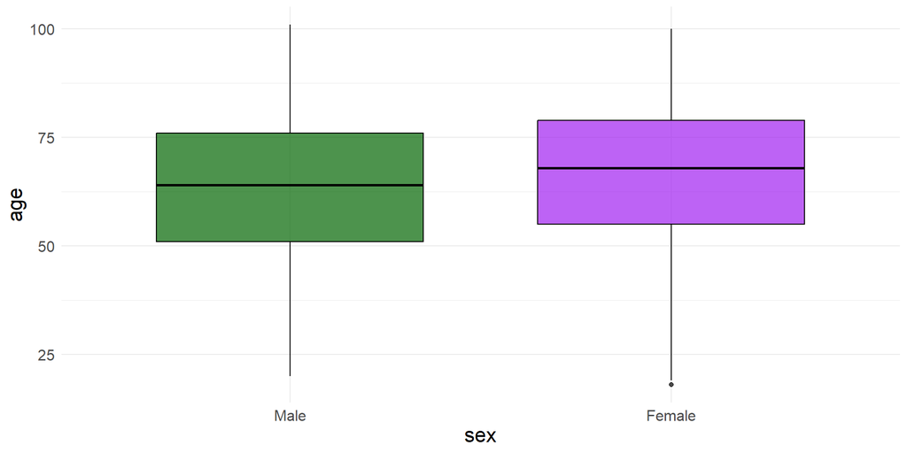

## `multi_plot()`

Spider plot

```r
multi_plot(
  comorbidities,
  radar = c("hypertension",
            "dyslipidemia",
            "dm",
            "mild_kidney_disease",
            "chronic_lung_disease"),
  radar_labels = c("Hypertension",
                    "Dyslipidemia",
                    "Diabetes",
                    "Mild CKD",
                    "COPD"),
  plot_type = "spider"
)
```

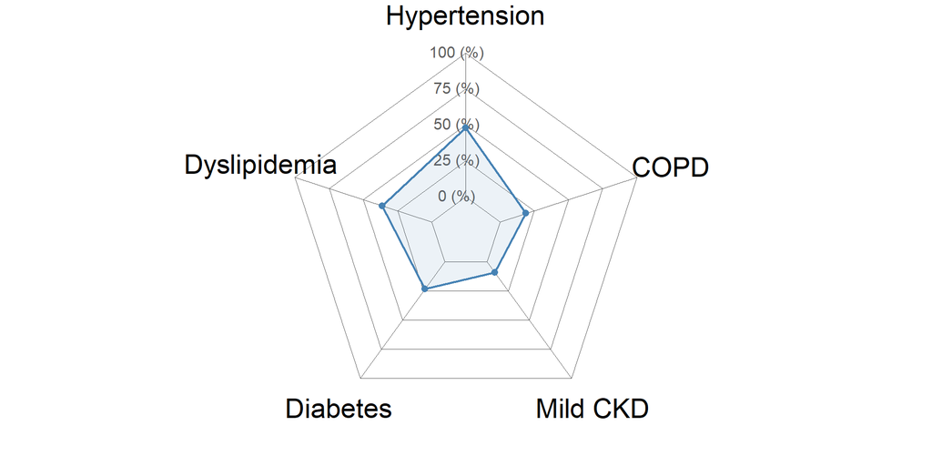

## `export_data()`

```r
export_data(cleaned, path = "cleaned_icu.csv")
```

```r
export_data(cleaned, path = "cleaned_icu_2025-12-04_v1", format = "txt")
```

**Tip**

File naming: include date and a short tag, e.g. `joined_2025-12-04_v1.xlsx`.

## Further information

You can visit the {DIVINE} website: https://bruigtp.github.io/DIVINE/

[figure not shown]

# Discussion

## Discussion

- The DIVINE R package provides 14 datasets and 6 functions
- Data includes variables commonly used in longitudinal and hospital-based analyses:
  - Validating predictive models, outcome incidence and prognostic factors
  - Teaching resource in biostatistics or epidemiology
- Functions can be used to inspect, clean, merge, summarize, visualize, and export data

[figure not shown]